# Final Project - Politics Logistic Regression Total

Logistic Regression

1.) First import all libraries that I might be using

```python
import statistics as stats
import statsmodels.api as sm
import pandas as pd
from sklearn.model_selection import train_test_split
import numpy as np
from sklearn.metrics import roc_curve, roc_auc_score, accuracy_score, confusion_matrix
import matplotlib.pyplot as plt
%matplotlib inline
```

2.) Read in .csv file and put into dataframe

```python
df = pd.read_csv("Election_Data_final.csv")
```

3.) There are a few variables where we know we don't need. Intuitively these would not be expected to have any predicive value to survival; Going to drop those.

```python
df.drop(['State','County','swing_county','dem_percent','rep_percent','vote_diff','percent_hispanic','percent_black'], axis=1, inplace=True)
```

```python
df.head()
```

|  | dem_won_2016 | dem_won_2012 | dem_won_2008 | voter_turnout | pop_estimate_2015 | net_population_change_2010-2015 | percent_poverty | percent_adults_college_degree | percent_white | 2015_unemployment_rate | median_household_income | percent_white_collar |
| --- | --- | --- | --- | --- | --- | --- | --- | --- | --- | --- | --- | --- |
| 0 | 1 | 1 | 1 | 35.2 | 10038388 | 344283 | 18.7 | 29.9 | 26.9 | 6.7 | 55686 | 60.3 |
| 1 | 1 | 1 | 1 | 52.3 | 5236393 | 38913 | 26.1 | 13.4 | 64.9 | 6.6 | 32408 | 47.7 |
| 2 | 1 | 1 | 1 | 39.9 | 4356362 | 429841 | 9.5 | 27.8 | 77.0 | 5.2 | 66249 | 62.5 |
| 3 | 0 | 0 | 0 | 39.9 | 4018143 | 342350 | 17.1 | 30.0 | 57.3 | 5.2 | 53929 | 63.8 |
| 4 | 1 | 1 | 1 | 41.9 | 3223096 | 195135 | 14.7 | 35.1 | 47.0 | 5.2 | 66034 | 64.2 |

4.) Next, assign test and train datasets, and add constnt term to both X datasets

```python
X_train, X_test, Y_train, Y_test = train_test_split(df.drop('dem_won_2016', axis=1),df['dem_won_2016'],test_size=0.2, random_state=156)
X_train = sm.add_constant(X_train)
X_test = sm.add_constant(X_test)
```

5.) Now fit the logistic regression model and view the results

```python
model1 = sm.GLM(Y_train, X_train, family=sm.families.Binomial())
result=model1.fit()
print(result.summary2())
```

```
                       Results: Generalized linear model
===============================================================================
Model:                   GLM                   AIC:                 675.2147
Link Function:           logit                 BIC:                 -18726.8395
Dependent Variable:      dem_won_2016          Log-Likelihood:      -325.61
Date:                    2019-10-15 11:41      LL-Null:             -1063.8
No. Observations:        2490                  Deviance:            651.21
Df Model:                11                    Pearson chi2:        2.62e+03
Df Residuals:            2478                  Scale:               1.0000
Method:                  IRLS
-------------------------------------------------------------------------------
                                 Coef.  Std.Err.    z    P>|z|   [0.025  0.975]
-------------------------------------------------------------------------------
const                           -2.5405   1.8735 -1.3560 0.1751 -6.2125  1.1314
dem_won_2012                     5.4583   0.3433 15.8985 0.0000  4.7854  6.1312
dem_won_2008                     0.0087   0.2230  0.0389 0.9690 -0.4284  0.4457
voter_turnout                   -0.0113   0.0098 -1.1496 0.2503 -0.0305  0.0079
pop_estimate_2015                0.0000   0.0000  3.5673 0.0004  0.0000  0.0000
net_population_change_2010-2015 -0.0000   0.0000 -1.5092 0.1312 -0.0000  0.0000
percent_poverty                  0.0593   0.0322  1.8398 0.0658 -0.0039  0.1224
percent_adults_college_degree    0.1426   0.0222  6.4346 0.0000  0.0992  0.1861
percent_white                   -0.0271   0.0065 -4.1492 0.0000 -0.0399 -0.0143
2015_unemployment_rate          -0.0283   0.0693 -0.4086 0.6828 -0.1642  0.1075
median_household_income         -0.0000   0.0000 -0.0457 0.9635 -0.0000  0.0000
percent_white_collar            -0.0773   0.0252 -3.0663 0.0022 -0.1267 -0.0279
===============================================================================
```

The AIC is 675. It looks like there are a few predictors whose p-value is above 0.05, indicating that these aren't significant at the 5% confidence level. We'll use Backward Elimination to remove the ones with the highest p-values first, and refit model each time to see how it looks.

```python
X_train.drop("dem_won_2008", axis=1, inplace=True)
print(sm.GLM(Y_train, X_train, family=sm.families.Binomial()).fit().summary2())
```

```
                       Results: Generalized linear model
===============================================================================
Model:                   GLM                   AIC:                 673.2162
Link Function:           logit                 BIC:                 -18734.6580
Dependent Variable:      dem_won_2016          Log-Likelihood:      -325.61
Date:                    2019-10-15 11:41      LL-Null:             -1063.8
No. Observations:        2490                  Deviance:            651.22
Df Model:                10                    Pearson chi2:        2.64e+03
Df Residuals:            2479                  Scale:               1.0000
Method:                  IRLS
-------------------------------------------------------------------------------
                                 Coef.  Std.Err.    z    P>|z|   [0.025  0.975]
-------------------------------------------------------------------------------
const                           -2.5329   1.8632 -1.3594 0.1740 -6.1847  1.1189
dem_won_2012                     5.4623   0.3272 16.6918 0.0000  4.8209  6.1037
voter_turnout                   -0.0113   0.0098 -1.1516 0.2495 -0.0305  0.0079
pop_estimate_2015                0.0000   0.0000  3.6166 0.0003  0.0000  0.0000
net_population_change_2010-2015 -0.0000   0.0000 -1.5277 0.1266 -0.0000  0.0000
percent_poverty                  0.0592   0.0321  1.8411 0.0656 -0.0038  0.1222
percent_adults_college_degree    0.1428   0.0219  6.5251 0.0000  0.0999  0.1856
percent_white                   -0.0271   0.0065 -4.1610 0.0000 -0.0399 -0.0144
2015_unemployment_rate          -0.0282   0.0693 -0.4075 0.6836 -0.1640  0.1075
median_household_income         -0.0000   0.0000 -0.0473 0.9623 -0.0000  0.0000
percent_white_collar            -0.0774   0.0251 -3.0839 0.0020 -0.1265 -0.0282
===============================================================================
```

```python
X_train.drop("median_household_income", axis=1, inplace=True)
print(sm.GLM(Y_train, X_train, family=sm.families.Binomial()).fit().summary2())
```

```
                       Results: Generalized linear model
===============================================================================
Model:                   GLM                   AIC:                 671.2184
Link Function:           logit                 BIC:                 -18742.4758
Dependent Variable:      dem_won_2016          Log-Likelihood:      -325.61
Date:                    2019-10-15 11:41      LL-Null:             -1063.8
No. Observations:        2490                  Deviance:            651.22
Df Model:                9                     Pearson chi2:        2.63e+03
Df Residuals:            2480                  Scale:               1.0000
Method:                  IRLS
-------------------------------------------------------------------------------
                                 Coef.  Std.Err.    z    P>|z|   [0.025  0.975]
-------------------------------------------------------------------------------
const                           -2.5830   1.5333 -1.6847 0.0921 -5.5881  0.4221
dem_won_2012                     5.4628   0.3271 16.6996 0.0000  4.8216  6.1039
voter_turnout                   -0.0113   0.0098 -1.1511 0.2497 -0.0304  0.0079
pop_estimate_2015                0.0000   0.0000  3.6194 0.0003  0.0000  0.0000
net_population_change_2010-2015 -0.0000   0.0000 -1.5280 0.1265 -0.0000  0.0000
percent_poverty                  0.0603   0.0227  2.6552 0.0079  0.0158  0.1047
percent_adults_college_degree    0.1424   0.0208  6.8538 0.0000  0.1017  0.1832
percent_white                   -0.0271   0.0063 -4.3065 0.0000 -0.0394 -0.0147
2015_unemployment_rate          -0.0284   0.0691 -0.4114 0.6808 -0.1639  0.1070
percent_white_collar            -0.0775   0.0249 -3.1163 0.0018 -0.1263 -0.0288
===============================================================================
```

```python
X_train.drop("2015_unemployment_rate", axis=1, inplace=True)
print(sm.GLM(Y_train, X_train, family=sm.families.Binomial()).fit().summary2())
```

```
                       Results: Generalized linear model
===============================================================================
Model:                   GLM                   AIC:                 669.3853
Link Function:           logit                 BIC:                 -18750.1290
Dependent Variable:      dem_won_2016          Log-Likelihood:      -325.69
Date:                    2019-10-15 11:41      LL-Null:             -1063.8
No. Observations:        2490                  Deviance:            651.39
Df Model:                8                     Pearson chi2:        2.58e+03
Df Residuals:            2481                  Scale:               1.0000
Method:                  IRLS
-------------------------------------------------------------------------------
                                 Coef.  Std.Err.    z    P>|z|   [0.025  0.975]
-------------------------------------------------------------------------------
const                           -2.7890   1.4469 -1.9276 0.0539 -5.6248  0.0468
dem_won_2012                     5.4589   0.3268 16.7055 0.0000  4.8185  6.0994
voter_turnout                   -0.0115   0.0098 -1.1792 0.2383 -0.0307  0.0076
pop_estimate_2015                0.0000   0.0000  3.6254 0.0003  0.0000  0.0000
net_population_change_2010-2015 -0.0000   0.0000 -1.4871 0.1370 -0.0000  0.0000
percent_poverty                  0.0568   0.0211  2.6947 0.0070  0.0155  0.0981
percent_adults_college_degree    0.1429   0.0207  6.8878 0.0000  0.1022  0.1836
percent_white                   -0.0264   0.0060 -4.3628 0.0000 -0.0382 -0.0145
percent_white_collar            -0.0763   0.0247 -3.0924 0.0020 -0.1247 -0.0279
===============================================================================
```

```python
X_train.drop("voter_turnout", axis=1, inplace=True)
print(sm.GLM(Y_train, X_train, family=sm.families.Binomial()).fit().summary2())
```

```
                       Results: Generalized linear model
===============================================================================
Model:                   GLM                   AIC:                 668.7766
Link Function:           logit                 BIC:                 -18756.5577
Dependent Variable:      dem_won_2016          Log-Likelihood:      -326.39
Date:                    2019-10-15 11:41      LL-Null:             -1063.8
No. Observations:        2490                  Deviance:            652.78
Df Model:                7                     Pearson chi2:        2.36e+03
Df Residuals:            2482                  Scale:               1.0000
Method:                  IRLS
-------------------------------------------------------------------------------
                                 Coef.  Std.Err.    z    P>|z|   [0.025  0.975]
-------------------------------------------------------------------------------
const                           -3.3129   1.3735 -2.4120 0.0159 -6.0050 -0.6209
dem_won_2012                     5.4114   0.3224 16.7844 0.0000  4.7795  6.0433
pop_estimate_2015                0.0000   0.0000  3.7540 0.0002  0.0000  0.0000
net_population_change_2010-2015 -0.0000   0.0000 -1.5562 0.1197 -0.0000  0.0000
percent_poverty                  0.0573   0.0210  2.7312 0.0063  0.0162  0.0985
percent_adults_college_degree    0.1407   0.0207  6.7866 0.0000  0.1001  0.1813
percent_white                   -0.0278   0.0059 -4.7270 0.0000 -0.0394 -0.0163
percent_white_collar            -0.0762   0.0247 -3.0810 0.0021 -0.1246 -0.0277
===============================================================================
```

```python
X_train.drop("net_population_change_2010-2015", axis=1, inplace=True)
print(sm.GLM(Y_train, X_train, family=sm.families.Binomial()).fit().summary2())
```

```
                      Results: Generalized linear model
=============================================================================
Model:                   GLM                  AIC:                669.2935
Link Function:           logit                BIC:                -18761.8608
Dependent Variable:      dem_won_2016         Log-Likelihood:     -327.65
Date:                    2019-10-15 11:41     LL-Null:            -1063.8
No. Observations:        2490                 Deviance:           655.29
Df Model:                6                    Pearson chi2:       2.31e+03
Df Residuals:            2483                 Scale:              1.0000
Method:                  IRLS
-----------------------------------------------------------------------------
                               Coef.  Std.Err.    z    P>|z|   [0.025  0.975]
-----------------------------------------------------------------------------
const                         -3.6076   1.3655 -2.6419 0.0082 -6.2840 -0.9312
dem_won_2012                   5.4986   0.3237 16.9876 0.0000  4.8642  6.1330
pop_estimate_2015              0.0000   0.0000  4.6923 0.0000  0.0000  0.0000
percent_poverty                0.0584   0.0210  2.7835 0.0054  0.0173  0.0995
percent_adults_college_degree  0.1379   0.0207  6.6442 0.0000  0.0972  0.1785
percent_white                 -0.0267   0.0058 -4.5788 0.0000 -0.0382 -0.0153
percent_white_collar          -0.0716   0.0245 -2.9181 0.0035 -0.1196 -0.0235
=============================================================================
```

```python
model_final = sm.GLM(Y_train, X_train, family=sm.families.Binomial())
result2=model_final.fit()
print(result2.summary2())
```

```
                      Results: Generalized linear model
=============================================================================
Model:                   GLM                  AIC:                669.2935
Link Function:           logit                BIC:                -18761.8608
Dependent Variable:      dem_won_2016         Log-Likelihood:     -327.65
Date:                    2019-10-15 11:41     LL-Null:            -1063.8
No. Observations:        2490                 Deviance:           655.29
Df Model:                6                    Pearson chi2:       2.31e+03
Df Residuals:            2483                 Scale:              1.0000
Method:                  IRLS
-----------------------------------------------------------------------------
                               Coef.  Std.Err.    z    P>|z|   [0.025  0.975]
-----------------------------------------------------------------------------
const                         -3.6076   1.3655 -2.6419 0.0082 -6.2840 -0.9312
dem_won_2012                   5.4986   0.3237 16.9876 0.0000  4.8642  6.1330
pop_estimate_2015              0.0000   0.0000  4.6923 0.0000  0.0000  0.0000
percent_poverty                0.0584   0.0210  2.7835 0.0054  0.0173  0.0995
percent_adults_college_degree  0.1379   0.0207  6.6442 0.0000  0.0972  0.1785
percent_white                 -0.0267   0.0058 -4.5788 0.0000 -0.0382 -0.0153
percent_white_collar          -0.0716   0.0245 -2.9181 0.0035 -0.1196 -0.0235
=============================================================================
```

Now all remaining variables are significant. The updated AIC (669) came down a little bit from the original run which is good. Now will take the exponent of the coefficents to better interpret them and see if they make sense.

```python
np.exp(result2.params)
```

```
const                              0.027116
dem_won_2012                     244.338368
pop_estimate_2015                  1.000002
percent_poverty                    1.060157
percent_adults_college_degree      1.147811
percent_white                      0.973608
percent_white_collar               0.930944
dtype: float64
```

6.) Next want to run the model on the test dataset and get probabilities of Democrate-2016.

```python
X_test.drop(['dem_won_2008','median_household_income','2015_unemployment_rate','voter_turnout','net_population_change_2010-2015'],axis=1,inplace=True)
#X_test.head()
probabilities = result2.predict(X_test)
```

7.) Can calculate the AUC value and create the AUC plot.

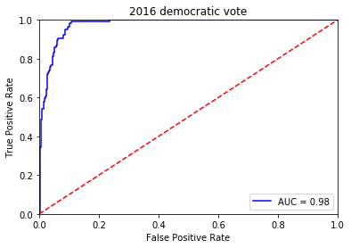

```python
auc = roc_auc_score(Y_test,probabilities)
fpr,tpr,threshold = roc_curve(Y_test,probabilities)
plt.title('2016 democratic vote')
plt.plot(fpr,tpr,'b',label = 'AUC = %0.2f' % auc)
plt.legend(loc = 'lower right')
plt.plot([0,1],[0,1], 'r--')
plt.xlim([0,1])
plt.ylim([0,1])
plt.ylabel('True Positive Rate')
plt.xlabel('False Positive Rate')
plt.show()
```

The calculated AUC value is .98 which is good as it's high, which means the model is doing a good job of classifying the dependent variable.

8.) Now want to calculate the optimal threshold probability, and use this to convert the predicted probabilities to predicted 1's and 0's for predicted Democrat_2016 value.

```python
optimal_idx = np.argmax(tpr - fpr)
optimal_threshold = threshold[optimal_idx]
optimal_threshold
```

```
0.06409265705039048
```

The optimal threshold turns out to be .064. Now can make new predictions, and classify dem_won_2016 = 1 if probability above this value.

```python
new_predictions = np.where(probabilities > optimal_threshold,1,0)
```

9.) Now calcualte the confusion matrix to see how well the model classified

```python
new_confusion_mat = confusion_matrix(Y_test, new_predictions)
new_confusion_df = pd.DataFrame(new_confusion_mat,index=['Actual No','Actual Yes'],columns=['Predicted No','Predicted Yes'])
new_confusion_df
```

|  | Predicted No | Predicted Yes |
| --- | --- | --- |
| Actual No | 460 | 56 |
| Actual Yes | 2 | 105 |

10.) Can calculate Accuracy to evaluate the results.

```python
accuracy_score(Y_test,new_predictions)
```

```
0.9069020866773676
```

The calculated Accuracy is .907, which is great! This is how many evaluations are being classified correctly out of the total # of observations in test dataset.

11.) Can calculate the pseudo-r squared

```python
sm.Logit(Y_train, X_train).fit().prsquared
```

```
Optimization terminated successfully.
         Current function value: 0.131585
         Iterations 9
```

```
0.6919902102438371
```